# BAAD: Above-Ground Biomass vs. Leaf Mass and Leaf Area Allometry

plant_scaling_data project

2026-05-12

# 1 Overview

This document focuses on the allometry between **total above-ground biomass** (`m.to`, kg) and two leaf-related traits measured on the same individual:

| Response | Symbol | Units |
| --- | --- | --- |
| Total leaf mass | `m.lf` | kg |
| Total leaf area | `a.lf` | m² |

Scaling relationships are estimated using **Standardised Major Axis (SMA)** regression on log₁₀-transformed data, which is the statistically appropriate method when both axes carry measurement error (Warton et al. 2006, *Biol. Rev.*). The null prediction under West–Brown–Enquist metabolic scaling theory is a 3/4-power relationship between leaf mass and plant mass (Enquist & Niklas 2002, *Nature*). The pipe model predicts leaf area scales approximately linearly with sapwood area and thus sub-linearly with AGB.

**BAAD citation:** Falster DS et al. (2015). BAAD: a Biomass And Allometry Database for woody plants. *Ecology* 96(5):1445. DOI: 10.1890/14-1889.1

```r
kable(data.frame(
  Dataset      = c("m.lf ~ m.to", "a.lf ~ m.to"),
  N_records    = c(nrow(d_lf), nrow(d_al)),
  N_species    = c(n_distinct(d_lf$speciesMatched), n_distinct(d_al$speciesMatched)),
  N_families   = c(n_distinct(d_lf$family[!is.na(d_lf$family)]),
                   n_distinct(d_al$family[!is.na(d_al$family)])),
  N_angiosperms = c(sum(!is.na(d_lf$clade) & d_lf$clade == "Angiosperm"),
                    sum(!is.na(d_al$clade) & d_al$clade == "Angiosperm")),
  N_gymnosperms = c(sum(!is.na(d_lf$clade) & d_lf$clade == "Gymnosperm"),
                    sum(!is.na(d_al$clade) & d_al$clade == "Gymnosperm"))
), caption = "Record counts for the two focal relationships")
```

Record counts for the two focal relationships

| Dataset | N_records | N_species | N_families | N_angiosperms | N_gymnosperms |
| --- | --- | --- | --- | --- | --- |
| m.lf ~ m.to | 8854 | 273 | 87 | 8277 | 577 |
| a.lf ~ m.to | 8198 | 238 | 81 | 7923 | 275 |

```r
# ── PGLS: species-mean data frames ───────────────────────────────────────────
sp_lf <- d_lf %>%
  filter(!is.na(speciesMatched), !is.na(family)) %>%
  group_by(speciesMatched) %>%
  summarise(
    log_mto = mean(log10(m.to), na.rm = TRUE),
    log_mlf = mean(log10(m.lf), na.rm = TRUE),
    family  = first(family),
    .groups = "drop"
  ) %>%
  drop_na() %>%
  mutate(sp_phylo = gsub(" ", "_", speciesMatched))

sp_al <- d_al %>%
  filter(!is.na(speciesMatched), !is.na(family)) %>%
  group_by(speciesMatched) %>%
  summarise(
    log_mto = mean(log10(m.to), na.rm = TRUE),
    log_al  = mean(log10(a.lf), na.rm = TRUE),
    family  = first(family),
    .groups = "drop"
  ) %>%
  drop_na() %>%
  mutate(sp_phylo = gsub(" ", "_", speciesMatched))

# ── Build backbone phylogeny via V.PhyloMaker2 ────────────────────────────────
species_list <- bind_rows(
  sp_lf %>% dplyr::select(species = speciesMatched, family),
  sp_al %>% dplyr::select(species = speciesMatched, family)
) %>%
  distinct(species, .keep_all = TRUE) %>%
  mutate(genus = sub(" .*", "", species)) %>%
  dplyr::select(species, genus, family)

baad_tree <- tryCatch({
  phy_out <- V.PhyloMaker2::phylo.maker(
    sp.list   = species_list,
    tree      = GBOTB.extended.TPL,
    nodes     = nodes.info.1.TPL,
    scenarios = "S3"
  )
  phy_out$scenario.3
}, error = function(e) {
  message("Phylogeny construction failed: ", conditionMessage(e))
  NULL
})
```

[output not shown]

[output cut: 27 more lines]

```r
if (!is.null(baad_tree)) {
  cat("Phylogeny built:", ape::Ntip(baad_tree), "tips\n")
} else {
  cat("baad_tree is NULL — PGLS will be skipped.\n")
}
```

```
## Phylogeny built: 268 tips
```

# 2 Interspecific scaling — all woody plants

## 2.1 Leaf mass ~ AGB

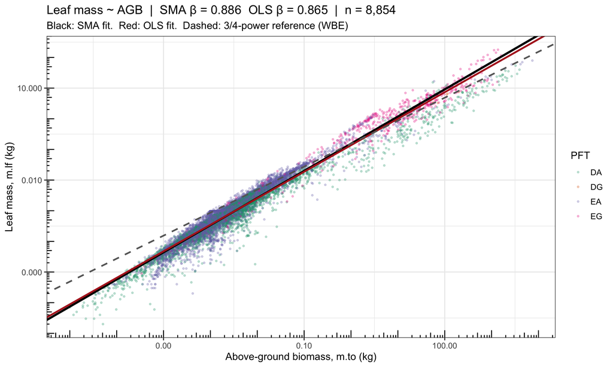

```r
fit_lf <- sma(log10(m.lf) ~ log10(m.to), data = d_lf)
sl_lf  <- round(coef(fit_lf)[2], 3)
int_lf <- round(coef(fit_lf)[1], 3)
r2_lf  <- round(cor(log10(d_lf$m.lf), log10(d_lf$m.to))^2, 3)

# OLS fit
lm_lf      <- lm(log10(m.lf) ~ log10(m.to), data = d_lf)
ols_sl_lf  <- round(coef(lm_lf)[2], 3)
ols_int_lf <- round(coef(lm_lf)[1], 3)
ols_ci_lf  <- round(confint(lm_lf)[2, ], 3)
ols_r2_lf  <- round(summary(lm_lf)$r.squared, 3)

ggplot(d_lf, aes(x = m.to, y = m.lf, colour = pft)) +
  geom_point(alpha = 0.25, size = 0.7) +
  geom_abline(intercept = int_lf, slope = sl_lf,
              colour = "black", linewidth = 1.2) +
  geom_abline(intercept = ols_int_lf, slope = ols_sl_lf,
              colour = "firebrick", linewidth = 1.0, linetype = "solid") +
  geom_abline(slope = 0.75, intercept = int_lf, linetype = "dashed",
              colour = "grey40", linewidth = 0.9) +
  scale_x_log10(labels = comma) +
  scale_y_log10(labels = comma) +
  scale_colour_brewer(palette = "Dark2", na.value = "grey70") +
  annotation_logticks() +
  labs(
    x = "Above-ground biomass, m.to (kg)",
    y = "Leaf mass, m.lf (kg)",
    colour = "PFT",
    title = paste0("Leaf mass ~ AGB  |  SMA β = ", sl_lf,
                   "  OLS β = ", ols_sl_lf,
                   "  |  n = ", format(nrow(d_lf), big.mark = ",")),
    subtitle = "Black: SMA fit.  Red: OLS fit.  Dashed: 3/4-power reference (WBE)"
  )
```

> **SMA result:** m.lf = 10^-0.813 × m.to^0.886  
> (n = 8,854; R² = 0.953)

```r
kable(data.frame(
  Method = c("OLS", "SMA"),
  Slope  = c(ols_sl_lf, sl_lf),
  CI_lo  = c(ols_ci_lf[1], round(fit_lf$coef[[1]][2, 2], 3)),
  CI_hi  = c(ols_ci_lf[2], round(fit_lf$coef[[1]][2, 3], 3)),
  R2     = c(ols_r2_lf, r2_lf)
),
col.names = c("Method", "Slope", "95% CI lo", "95% CI hi", "R²"),
caption   = "OLS vs. SMA comparison — leaf mass ~ AGB")
```

OLS vs. SMA comparison — leaf mass ~ AGB

|  | Method | Slope | 95% CI lo | 95% CI hi | R² |
| --- | --- | --- | --- | --- | --- |
| log10(m.to) | OLS | 0.865 | 0.861 | 0.869 | 0.953 |
| slope | SMA | 0.886 | 0.882 | 0.890 | 0.953 |

## 2.2 Leaf area ~ AGB

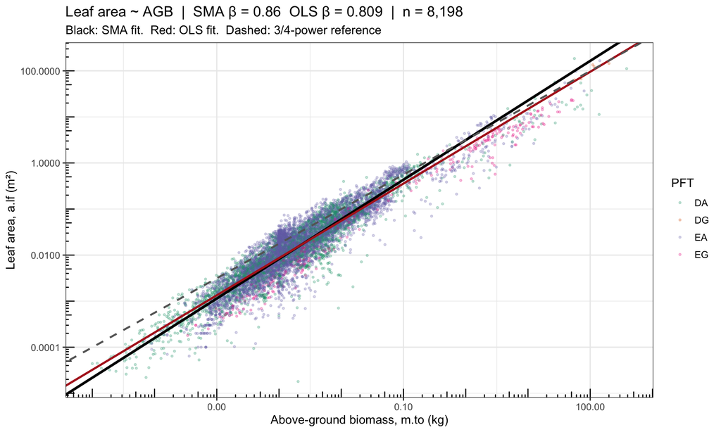

```r
fit_al <- sma(log10(a.lf) ~ log10(m.to), data = d_al)
sl_al  <- round(coef(fit_al)[2], 3)
int_al <- round(coef(fit_al)[1], 3)
r2_al  <- round(cor(log10(d_al$a.lf), log10(d_al$m.to))^2, 3)

# OLS fit
lm_al      <- lm(log10(a.lf) ~ log10(m.to), data = d_al)
ols_sl_al  <- round(coef(lm_al)[2], 3)
ols_int_al <- round(coef(lm_al)[1], 3)
ols_ci_al  <- round(confint(lm_al)[2, ], 3)
ols_r2_al  <- round(summary(lm_al)$r.squared, 3)

ggplot(d_al, aes(x = m.to, y = a.lf, colour = pft)) +
  geom_point(alpha = 0.25, size = 0.7) +
  geom_abline(intercept = int_al, slope = sl_al,
              colour = "black", linewidth = 1.2) +
  geom_abline(intercept = ols_int_al, slope = ols_sl_al,
              colour = "firebrick", linewidth = 1.0, linetype = "solid") +
  geom_abline(slope = 0.75, intercept = int_al, linetype = "dashed",
              colour = "grey40", linewidth = 0.9) +
  scale_x_log10(labels = comma) +
  scale_y_log10(labels = comma) +
  scale_colour_brewer(palette = "Dark2", na.value = "grey70") +
  annotation_logticks() +
  labs(
    x = "Above-ground biomass, m.to (kg)",
    y = "Leaf area, a.lf (m²)",
    colour = "PFT",
    title = paste0("Leaf area ~ AGB  |  SMA β = ", sl_al,
                   "  OLS β = ", ols_sl_al,
                   "  |  n = ", format(nrow(d_al), big.mark = ",")),
    subtitle = "Black: SMA fit.  Red: OLS fit.  Dashed: 3/4-power reference"
  )
```

> **SMA result:** a.lf = 10^0.497 × m.to^0.86  
> (n = 8,198; R² = 0.886)

```r
kable(data.frame(
  Method = c("OLS", "SMA"),
  Slope  = c(ols_sl_al, sl_al),
  CI_lo  = c(ols_ci_al[1], round(fit_al$coef[[1]][2, 2], 3)),
  CI_hi  = c(ols_ci_al[2], round(fit_al$coef[[1]][2, 3], 3)),
  R2     = c(ols_r2_al, r2_al)
),
col.names = c("Method", "Slope", "95% CI lo", "95% CI hi", "R²"),
caption   = "OLS vs. SMA comparison — leaf area ~ AGB")
```

OLS vs. SMA comparison — leaf area ~ AGB

|  | Method | Slope | 95% CI lo | 95% CI hi | R² |
| --- | --- | --- | --- | --- | --- |
| log10(m.to) | OLS | 0.809 | 0.803 | 0.815 | 0.886 |
| slope | SMA | 0.860 | 0.853 | 0.866 | 0.886 |

# 3 Angiosperm vs. Gymnosperm

## 3.1 Leaf mass ~ AGB by clade

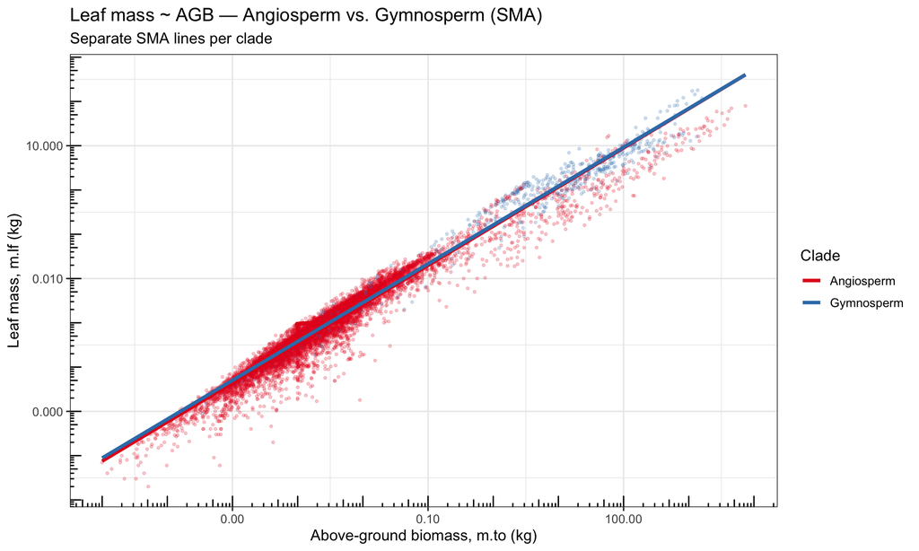

```r
d_lf_c <- d_lf %>% filter(!is.na(clade))

# Fit SMA per clade
clade_lf <- d_lf_c %>%
  group_by(clade) %>%
  group_modify(~ {
    tryCatch({
      lx  <- log10(.x$m.to)
      ly  <- log10(.x$m.lf)
      fit <- sma(ly ~ lx)
      cm  <- fit$coef[[1]]
      data.frame(
        n         = nrow(.x),
        intercept = cm[1, 1],
        slope     = cm[2, 1],
        slope_lo  = cm[2, 2],
        slope_hi  = cm[2, 3],
        r2        = cor(lx, ly)^2
      )
    }, error = function(e) {
      data.frame(n = nrow(.x), intercept = NA, slope = NA,
                 slope_lo = NA, slope_hi = NA, r2 = NA)
    })
  }) %>%
  ungroup()

# OLS per clade — leaf mass
ols_clade_lf <- d_lf_c %>%
  group_by(clade) %>%
  group_modify(~ {
    tryCatch({
      fit <- lm(log10(.x$m.lf) ~ log10(.x$m.to))
      ci  <- confint(fit)
      data.frame(ols_slope = round(coef(fit)[2], 3),
                 ols_slope_lo = round(ci[2, 1], 3),
                 ols_slope_hi = round(ci[2, 2], 3))
    }, error = function(e) {
      data.frame(ols_slope = NA_real_, ols_slope_lo = NA_real_, ols_slope_hi = NA_real_)
    })
  }) %>%
  ungroup()
clade_lf <- clade_lf %>% left_join(ols_clade_lf, by = "clade")

# Build prediction lines across AGB range
pred_range <- seq(log10(min(d_lf_c$m.to)), log10(max(d_lf_c$m.to)), length.out = 200)

clade_lines_lf <- clade_lf %>%
  rowwise() %>%
  mutate(log_x = list(pred_range),
         log_y = list(intercept + slope * pred_range)) %>%
  unnest(c(log_x, log_y)) %>%
  mutate(x = 10^log_x, y = 10^log_y)

ggplot(d_lf_c, aes(x = m.to, y = m.lf, colour = clade)) +
  geom_point(alpha = 0.2, size = 0.7) +
  geom_line(data = clade_lines_lf, aes(x = x, y = y, colour = clade),
            linewidth = 1.3) +
  scale_x_log10(labels = comma) +
  scale_y_log10(labels = comma) +
  scale_colour_manual(values = c(Angiosperm = "#e41a1c", Gymnosperm = "#377eb8")) +
  annotation_logticks() +
  labs(
    x = "Above-ground biomass, m.to (kg)",
    y = "Leaf mass, m.lf (kg)",
    colour = "Clade",
    title = "Leaf mass ~ AGB — Angiosperm vs. Gymnosperm (SMA)",
    subtitle = "Separate SMA lines per clade"
  )
```

```r
kable(clade_lf %>%
        mutate(across(where(is.numeric), ~ round(.x, 3))) %>%
        dplyr::select(clade, n, slope, slope_lo, slope_hi, ols_slope, ols_slope_lo, ols_slope_hi, r2),
      col.names = c("Clade", "N", "SMA slope", "SMA CI lo", "SMA CI hi",
                    "OLS slope", "OLS CI lo", "OLS CI hi", "R²"),
      caption = "SMA and OLS slopes for leaf mass ~ AGB by clade")
```

SMA and OLS slopes for leaf mass ~ AGB by clade

| Clade | N | SMA slope | SMA CI lo | SMA CI hi | OLS slope | OLS CI lo | OLS CI hi | R² |
| --- | --- | --- | --- | --- | --- | --- | --- | --- |
| Angiosperm | 8277 | 0.884 | 0.879 | 0.889 | 0.855 | 0.850 | 0.860 | 0.935 |
| Gymnosperm | 577 | 0.877 | 0.866 | 0.888 | 0.867 | 0.856 | 0.878 | 0.977 |

## 3.2 Leaf area ~ AGB by clade

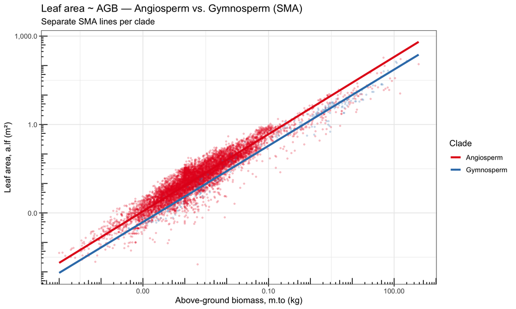

```r
d_al_c <- d_al %>% filter(!is.na(clade))

clade_al <- d_al_c %>%
  group_by(clade) %>%
  group_modify(~ {
    tryCatch({
      lx  <- log10(.x$m.to)
      ly  <- log10(.x$a.lf)
      fit <- sma(ly ~ lx)
      cm  <- fit$coef[[1]]
      data.frame(
        n         = nrow(.x),
        intercept = cm[1, 1],
        slope     = cm[2, 1],
        slope_lo  = cm[2, 2],
        slope_hi  = cm[2, 3],
        r2        = cor(lx, ly)^2
      )
    }, error = function(e) {
      data.frame(n = nrow(.x), intercept = NA, slope = NA,
                 slope_lo = NA, slope_hi = NA, r2 = NA)
    })
  }) %>%
  ungroup()

# OLS per clade — leaf area
ols_clade_al <- d_al_c %>%
  group_by(clade) %>%
  group_modify(~ {
    tryCatch({
      fit <- lm(log10(.x$a.lf) ~ log10(.x$m.to))
      ci  <- confint(fit)
      data.frame(ols_slope = round(coef(fit)[2], 3),
                 ols_slope_lo = round(ci[2, 1], 3),
                 ols_slope_hi = round(ci[2, 2], 3))
    }, error = function(e) {
      data.frame(ols_slope = NA_real_, ols_slope_lo = NA_real_, ols_slope_hi = NA_real_)
    })
  }) %>%
  ungroup()
clade_al <- clade_al %>% left_join(ols_clade_al, by = "clade")

pred_range_al <- seq(log10(min(d_al_c$m.to)), log10(max(d_al_c$m.to)), length.out = 200)

clade_lines_al <- clade_al %>%
  rowwise() %>%
  mutate(log_x = list(pred_range_al),
         log_y = list(intercept + slope * pred_range_al)) %>%
  unnest(c(log_x, log_y)) %>%
  mutate(x = 10^log_x, y = 10^log_y)

ggplot(d_al_c, aes(x = m.to, y = a.lf, colour = clade)) +
  geom_point(alpha = 0.2, size = 0.7) +
  geom_line(data = clade_lines_al, aes(x = x, y = y, colour = clade),
            linewidth = 1.3) +
  scale_x_log10(labels = comma) +
  scale_y_log10(labels = comma) +
  scale_colour_manual(values = c(Angiosperm = "#e41a1c", Gymnosperm = "#377eb8")) +
  annotation_logticks() +
  labs(
    x = "Above-ground biomass, m.to (kg)",
    y = "Leaf area, a.lf (m²)",
    colour = "Clade",
    title = "Leaf area ~ AGB — Angiosperm vs. Gymnosperm (SMA)",
    subtitle = "Separate SMA lines per clade"
  )
```

```r
kable(clade_al %>%
        mutate(across(where(is.numeric), ~ round(.x, 3))) %>%
        dplyr::select(clade, n, slope, slope_lo, slope_hi, ols_slope, ols_slope_lo, ols_slope_hi, r2),
      col.names = c("Clade", "N", "SMA slope", "SMA CI lo", "SMA CI hi",
                    "OLS slope", "OLS CI lo", "OLS CI hi", "R²"),
      caption = "SMA and OLS slopes for leaf area ~ AGB by clade")
```

SMA and OLS slopes for leaf area ~ AGB by clade

| Clade | N | SMA slope | SMA CI lo | SMA CI hi | OLS slope | OLS CI lo | OLS CI hi | R² |
| --- | --- | --- | --- | --- | --- | --- | --- | --- |
| Angiosperm | 7923 | 0.873 | 0.867 | 0.880 | 0.818 | 0.811 | 0.824 | 0.876 |
| Gymnosperm | 275 | 0.862 | 0.848 | 0.877 | 0.854 | 0.839 | 0.868 | 0.980 |

# 4 Phylogenetic regression (PGLS)

```r
# Initialise result holders in the global chunk environment
pgls_lf_fit    <- NULL
pgls_al_fit    <- NULL
pgls_lf_result <- NULL
pgls_al_result <- NULL

if (!is.null(baad_tree)) {
  tree_tips <- baad_tree$tip.label

  # --- Leaf mass ~ AGB PGLS ---
  sp_lf_match  <- sp_lf %>% filter(sp_phylo %in% tree_tips)
  n_matched_lf <- nrow(sp_lf_match)
  cat("Leaf mass: species matched to tree:", n_matched_lf, "of", nrow(sp_lf), "\n")
  if (n_matched_lf >= 10) {
    tryCatch({
      tree_lf      <- ape::drop.tip(baad_tree, setdiff(tree_tips, sp_lf_match$sp_phylo))
      df_lf_pgls   <- as.data.frame(sp_lf_match)
      rownames(df_lf_pgls) <- df_lf_pgls$sp_phylo
      cd_lf        <- caper::comparative.data(phy = tree_lf, data = df_lf_pgls,
                                              names.col = "sp_phylo", warn.dropped = FALSE)
      pgls_lf_fit  <- caper::pgls(log_mlf ~ log_mto, data = cd_lf, lambda = "ML")
      pgls_lf_result <- list(
        n       = n_matched_lf,
        slope   = round(coef(pgls_lf_fit)[2], 3),
        se      = round(summary(pgls_lf_fit)$coefficients[2, 2], 3),
        lambda  = round(pgls_lf_fit$param[["lambda"]], 3),
        p_value = round(summary(pgls_lf_fit)$coefficients[2, 4], 4)
      )
    }, error = function(e) message("Leaf mass PGLS failed: ", conditionMessage(e)))
  }

  # --- Leaf area ~ AGB PGLS ---
  sp_al_match  <- sp_al %>% filter(sp_phylo %in% tree_tips)
  n_matched_al <- nrow(sp_al_match)
  cat("Leaf area: species matched to tree:", n_matched_al, "of", nrow(sp_al), "\n")
  if (n_matched_al >= 10) {
    tryCatch({
      tree_al      <- ape::drop.tip(baad_tree, setdiff(tree_tips, sp_al_match$sp_phylo))
      df_al_pgls   <- as.data.frame(sp_al_match)
      rownames(df_al_pgls) <- df_al_pgls$sp_phylo
      cd_al        <- caper::comparative.data(phy = tree_al, data = df_al_pgls,
                                              names.col = "sp_phylo", warn.dropped = FALSE)
      pgls_al_fit  <- caper::pgls(log_al ~ log_mto, data = cd_al, lambda = "ML")
      pgls_al_result <- list(
        n       = n_matched_al,
        slope   = round(coef(pgls_al_fit)[2], 3),
        se      = round(summary(pgls_al_fit)$coefficients[2, 2], 3),
        lambda  = round(pgls_al_fit$param[["lambda"]], 3),
        p_value = round(summary(pgls_al_fit)$coefficients[2, 4], 4)
      )
    }, error = function(e) message("Leaf area PGLS failed: ", conditionMessage(e)))
  }
} else {
  cat("Phylogeny construction failed; PGLS skipped.\n")
}
```

```
## Leaf mass: species matched to tree: 268 of 268
```

```
## Leaf area: species matched to tree: 237 of 237
```

## 4.1 Leaf mass ~ AGB (PGLS)

```r
if (!is.null(pgls_lf_result)) {
  kable(data.frame(
    Method  = "PGLS (Brownian motion, λ ML)",
    N_sp    = pgls_lf_result$n,
    Slope   = pgls_lf_result$slope,
    SE      = pgls_lf_result$se,
    Lambda  = pgls_lf_result$lambda,
    P_value = pgls_lf_result$p_value
  ),
  col.names = c("Method", "N species", "Slope", "SE", "Pagel's λ (ML)", "p-value"),
  caption = "PGLS result — leaf mass ~ AGB (species means)")
} else {
  cat("PGLS not available for leaf mass ~ AGB.\n")
}
```

```
## PGLS not available for leaf mass ~ AGB.
```

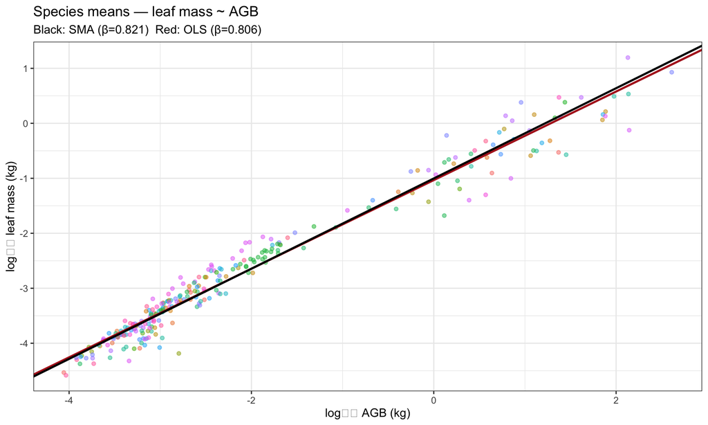

```r
if (nrow(sp_lf) > 0) {
  ols_sp_lf     <- lm(log_mlf ~ log_mto, data = sp_lf)
  sma_sp_lf     <- sma(log_mlf ~ log_mto, data = sp_lf)
  sma_sp_lf_int <- sma_sp_lf$coef[[1]][1, 1]
  sma_sp_lf_sl  <- sma_sp_lf$coef[[1]][2, 1]

  subtitle_lf <- paste0(
    "Black: SMA (β=", round(sma_sp_lf_sl, 3), ")",
    "  Red: OLS (β=", round(coef(ols_sp_lf)[2], 3), ")",
    if (!is.null(pgls_lf_result)) paste0("  Green: PGLS (β=", pgls_lf_result$slope, ")") else ""
  )

  p_pgls_lf <- ggplot(sp_lf, aes(x = log_mto, y = log_mlf)) +
    geom_point(aes(colour = family), alpha = 0.5, size = 1.5, show.legend = FALSE) +
    geom_abline(intercept = coef(ols_sp_lf)[1], slope = coef(ols_sp_lf)[2],
                colour = "firebrick", linewidth = 1.0) +
    geom_abline(intercept = sma_sp_lf_int, slope = sma_sp_lf_sl,
                colour = "black", linewidth = 1.0) +
    labs(x = "log₁₀ AGB (kg)", y = "log₁₀ leaf mass (kg)",
         title = "Species means — leaf mass ~ AGB", subtitle = subtitle_lf)

  if (!is.null(pgls_lf_fit)) {
    p_pgls_lf <- p_pgls_lf +
      geom_abline(intercept = coef(pgls_lf_fit)[1], slope = coef(pgls_lf_fit)[2],
                  colour = "darkgreen", linewidth = 1.0, linetype = "dashed")
  }
  print(p_pgls_lf)
}
```

## 4.2 Leaf area ~ AGB (PGLS)

```r
if (!is.null(pgls_al_result)) {
  kable(data.frame(
    Method  = "PGLS (Brownian motion, λ ML)",
    N_sp    = pgls_al_result$n,
    Slope   = pgls_al_result$slope,
    SE      = pgls_al_result$se,
    Lambda  = pgls_al_result$lambda,
    P_value = pgls_al_result$p_value
  ),
  col.names = c("Method", "N species", "Slope", "SE", "Pagel's λ (ML)", "p-value"),
  caption = "PGLS result — leaf area ~ AGB (species means)")
} else {
  cat("PGLS not available for leaf area ~ AGB.\n")
}
```

```
## PGLS not available for leaf area ~ AGB.
```

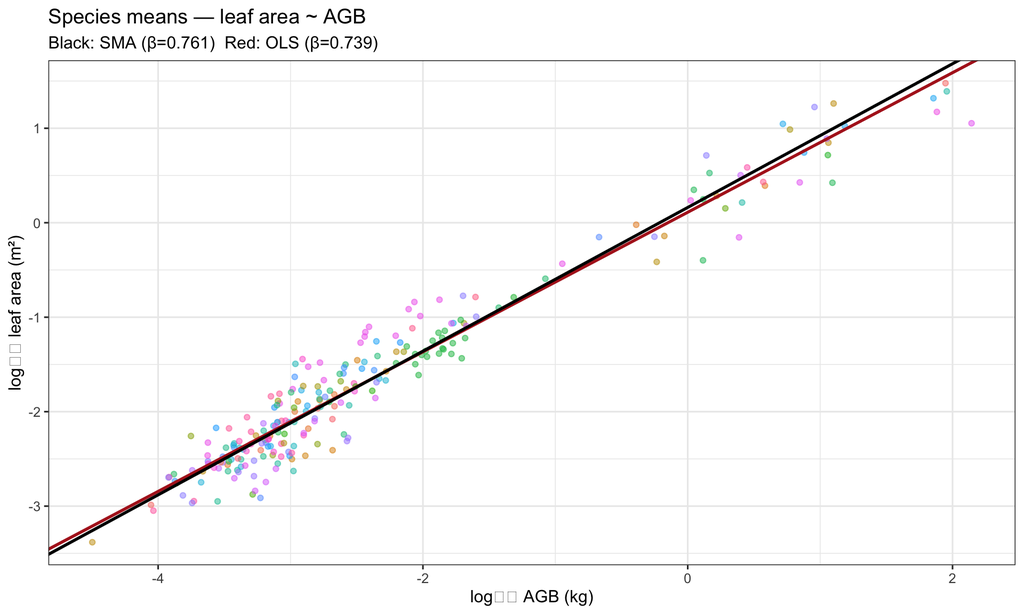

```r
if (nrow(sp_al) > 0) {
  ols_sp_al     <- lm(log_al ~ log_mto, data = sp_al)
  sma_sp_al     <- sma(log_al ~ log_mto, data = sp_al)
  sma_sp_al_int <- sma_sp_al$coef[[1]][1, 1]
  sma_sp_al_sl  <- sma_sp_al$coef[[1]][2, 1]

  subtitle_al <- paste0(
    "Black: SMA (β=", round(sma_sp_al_sl, 3), ")",
    "  Red: OLS (β=", round(coef(ols_sp_al)[2], 3), ")",
    if (!is.null(pgls_al_result)) paste0("  Green: PGLS (β=", pgls_al_result$slope, ")") else ""
  )

  p_pgls_al <- ggplot(sp_al, aes(x = log_mto, y = log_al)) +
    geom_point(aes(colour = family), alpha = 0.5, size = 1.5, show.legend = FALSE) +
    geom_abline(intercept = coef(ols_sp_al)[1], slope = coef(ols_sp_al)[2],
                colour = "firebrick", linewidth = 1.0) +
    geom_abline(intercept = sma_sp_al_int, slope = sma_sp_al_sl,
                colour = "black", linewidth = 1.0) +
    labs(x = "log₁₀ AGB (kg)", y = "log₁₀ leaf area (m²)",
         title = "Species means — leaf area ~ AGB", subtitle = subtitle_al)

  if (!is.null(pgls_al_fit)) {
    p_pgls_al <- p_pgls_al +
      geom_abline(intercept = coef(pgls_al_fit)[1], slope = coef(pgls_al_fit)[2],
                  colour = "darkgreen", linewidth = 1.0, linetype = "dashed")
  }
  print(p_pgls_al)
}
```

# 5 Family-level scaling

SMA regression fitted for each plant family with ≥ 30 individual records having both `m.to` and the relevant leaf trait measured. Families are sorted by slope. The **3/4-power reference line** is shown in grey.

## 5.1 Leaf mass ~ AGB by family

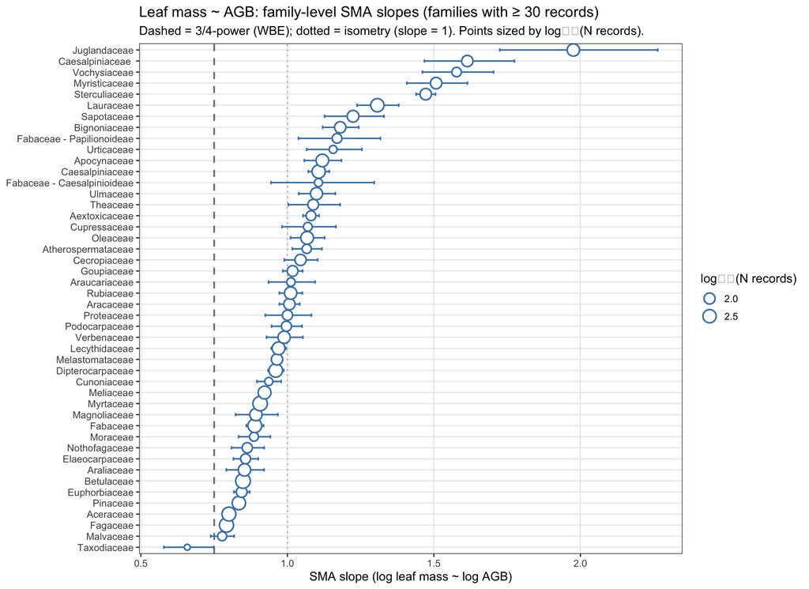

```r
# ── Minimum records per family to estimate a regression ──────────────────────
MIN_N_FAM <- 30

fam_lf_counts <- d_lf %>%
  filter(!is.na(family)) %>%
  count(family) %>%
  filter(n >= MIN_N_FAM) %>%
  pull(family)

fam_lf_slopes <- d_lf %>%
  filter(!is.na(family), family %in% fam_lf_counts) %>%
  group_by(family) %>%
  group_modify(~ {
    tryCatch({
      lx  <- log10(.x$m.to)
      ly  <- log10(.x$m.lf)
      fit <- sma(ly ~ lx)
      cm  <- fit$coef[[1]]
      data.frame(
        n         = nrow(.x),
        n_sp      = n_distinct(.x$speciesMatched),
        intercept = cm[1, 1],
        slope     = cm[2, 1],
        slope_lo  = cm[2, 2],
        slope_hi  = cm[2, 3],
        r2        = cor(lx, ly)^2
      )
    }, error = function(e) {
      data.frame(n = nrow(.x), n_sp = n_distinct(.x$speciesMatched),
                 intercept = NA, slope = NA, slope_lo = NA, slope_hi = NA, r2 = NA)
    })
  }) %>%
  ungroup() %>%
  filter(!is.na(slope)) %>%
  arrange(slope)

# OLS per family — leaf mass
fam_lf_ols <- d_lf %>%
  filter(!is.na(family), family %in% fam_lf_counts) %>%
  group_by(family) %>%
  group_modify(~ {
    tryCatch({
      fit <- lm(log10(.x$m.lf) ~ log10(.x$m.to))
      data.frame(ols_slope = round(coef(fit)[2], 3))
    }, error = function(e) data.frame(ols_slope = NA_real_))
  }) %>%
  ungroup()
fam_lf_slopes <- fam_lf_slopes %>% left_join(fam_lf_ols, by = "family")

# Forest-style dot-range plot─
ggplot(fam_lf_slopes, aes(x = slope, y = reorder(family, slope))) +
  geom_vline(xintercept = 0.75, colour = "grey50", linetype = "dashed", linewidth = 0.8) +
  geom_vline(xintercept = 1.00, colour = "grey70", linetype = "dotted", linewidth = 0.6) +
  geom_errorbarh(aes(xmin = slope_lo, xmax = slope_hi),
                 height = 0.3, colour = "steelblue", linewidth = 0.7) +
  geom_point(aes(size = log10(n)), colour = "steelblue", fill = "white", shape = 21,
             stroke = 1.1) +
  scale_size_continuous(range = c(2, 6), name = "log₁₀(N records)") +
  labs(
    x = "SMA slope (log leaf mass ~ log AGB)",
    y = NULL,
    title = paste0("Leaf mass ~ AGB: family-level SMA slopes (families with ≥ ", MIN_N_FAM, " records)"),
    subtitle = "Dashed = 3/4-power (WBE); dotted = isometry (slope = 1). Points sized by log₁₀(N records)."
  ) +
  theme(panel.grid.major.y = element_line(colour = "grey92"),
        panel.grid.minor   = element_blank())
```

```r
kable(
  fam_lf_slopes %>%
    arrange(desc(n)) %>%
    mutate(across(c(slope, slope_lo, slope_hi, r2, intercept, ols_slope), ~ round(.x, 3))) %>%
    dplyr::select(family, n, n_sp, slope, slope_lo, slope_hi, ols_slope, r2),
  col.names = c("Family", "N records", "N species", "SMA slope",
                "SMA CI lo", "SMA CI hi", "OLS slope", "R²"),
  caption = paste0("Family-level SMA and OLS slopes — leaf mass ~ AGB (≥ ", MIN_N_FAM, " records)")
)
```

Family-level SMA and OLS slopes — leaf mass ~ AGB (≥ 30 records)

| Family | N records | N species | SMA slope | SMA CI lo | SMA CI hi | OLS slope | R² |
| --- | --- | --- | --- | --- | --- | --- | --- |
| Betulaceae | 847 | 8 | 0.848 | 0.839 | 0.858 | 0.836 | 0.971 |
| Myrtaceae | 715 | 12 | 0.907 | 0.896 | 0.918 | 0.895 | 0.975 |
| Fagaceae | 539 | 9 | 0.792 | 0.781 | 0.804 | 0.781 | 0.971 |
| Aceraceae | 478 | 4 | 0.800 | 0.789 | 0.812 | 0.791 | 0.976 |
| Fabaceae | 449 | 5 | 0.889 | 0.860 | 0.919 | 0.830 | 0.873 |
| Dipterocarpaceae | 373 | 20 | 0.960 | 0.934 | 0.987 | 0.924 | 0.926 |
| Pinaceae | 359 | 7 | 0.834 | 0.814 | 0.855 | 0.810 | 0.943 |
| Lauraceae | 319 | 11 | 1.307 | 1.238 | 1.380 | 1.137 | 0.756 |
| Caesalpiniaceae | 315 | 3 | 1.107 | 1.071 | 1.143 | 1.059 | 0.915 |
| Meliaceae | 245 | 5 | 0.922 | 0.902 | 0.943 | 0.908 | 0.969 |
| Lecythidaceae | 236 | 4 | 0.970 | 0.945 | 0.995 | 0.950 | 0.959 |
| Oleaceae | 227 | 3 | 1.067 | 1.011 | 1.127 | 0.971 | 0.828 |
| Apocynaceae | 217 | 4 | 1.119 | 1.058 | 1.184 | 1.015 | 0.823 |
| Araliaceae | 185 | 5 | 0.853 | 0.791 | 0.920 | 0.730 | 0.731 |
| Rubiaceae | 184 | 20 | 1.011 | 0.972 | 1.051 | 0.975 | 0.929 |
| Juglandaceae | 184 | 1 | 1.976 | 1.725 | 2.264 | 0.711 | 0.129 |
| Magnoliaceae | 175 | 3 | 0.893 | 0.823 | 0.968 | 0.752 | 0.710 |
| Verbenaceae | 174 | 4 | 0.989 | 0.929 | 1.053 | 0.899 | 0.826 |
| Ulmaceae | 166 | 5 | 1.099 | 1.038 | 1.164 | 1.021 | 0.864 |
| Sapotaceae | 134 | 3 | 1.224 | 1.127 | 1.330 | 1.073 | 0.768 |
| Sterculiaceae | 119 | 1 | 1.472 | 1.439 | 1.506 | 1.461 | 0.985 |
| Myristicaceae | 118 | 1 | 1.508 | 1.408 | 1.615 | 1.399 | 0.861 |
| Aracaceae | 113 | 1 | 1.007 | 0.973 | 1.042 | 0.990 | 0.966 |
| Melastomataceae | 111 | 2 | 0.965 | 0.950 | 0.979 | 0.961 | 0.994 |
| Bignoniaceae | 111 | 2 | 1.180 | 1.120 | 1.244 | 1.135 | 0.924 |
| Caesalpiniaceae | 111 | 1 | 1.614 | 1.468 | 1.775 | 1.397 | 0.749 |
| Cecropiaceae | 107 | 1 | 1.045 | 0.989 | 1.103 | 1.002 | 0.920 |
| Goupiaceae | 88 | 1 | 1.018 | 0.984 | 1.052 | 1.005 | 0.976 |
| Euphorbiaceae | 87 | 10 | 0.844 | 0.817 | 0.871 | 0.834 | 0.978 |
| Theaceae | 86 | 5 | 1.088 | 1.003 | 1.180 | 1.009 | 0.860 |
| Nothofagaceae | 72 | 5 | 0.863 | 0.809 | 0.921 | 0.831 | 0.927 |
| Proteaceae | 71 | 4 | 1.000 | 0.925 | 1.082 | 0.945 | 0.893 |
| Podocarpaceae | 68 | 5 | 0.997 | 0.946 | 1.050 | 0.974 | 0.955 |
| Elaeocarpaceae | 65 | 2 | 0.857 | 0.816 | 0.901 | 0.840 | 0.961 |
| Aextoxicaceae | 61 | 1 | 1.080 | 1.054 | 1.108 | 1.075 | 0.991 |
| Fabaceae - Papilionoideae | 60 | 4 | 1.169 | 1.038 | 1.318 | 1.041 | 0.793 |
| Vochysiaceae | 55 | 1 | 1.578 | 1.461 | 1.704 | 1.515 | 0.922 |
| Atherospermataceae | 51 | 2 | 1.066 | 1.017 | 1.118 | 1.051 | 0.973 |
| Malvaceae | 49 | 2 | 0.777 | 0.738 | 0.818 | 0.765 | 0.969 |
| Moraceae | 48 | 7 | 0.886 | 0.833 | 0.942 | 0.867 | 0.957 |
| Cupressaceae | 46 | 2 | 1.070 | 0.981 | 1.166 | 1.026 | 0.920 |
| Araucariaceae | 43 | 2 | 1.012 | 0.936 | 1.095 | 0.980 | 0.938 |
| Cunoniaceae | 40 | 3 | 0.936 | 0.896 | 0.979 | 0.928 | 0.982 |
| Fabaceae - Caesalpinioideae | 40 | 4 | 1.106 | 0.944 | 1.296 | 0.967 | 0.765 |
| Urticaceae | 39 | 4 | 1.156 | 1.066 | 1.254 | 1.121 | 0.940 |
| Taxodiaceae | 33 | 1 | 0.658 | 0.578 | 0.749 | 0.616 | 0.875 |

## 5.2 Leaf area ~ AGB by family

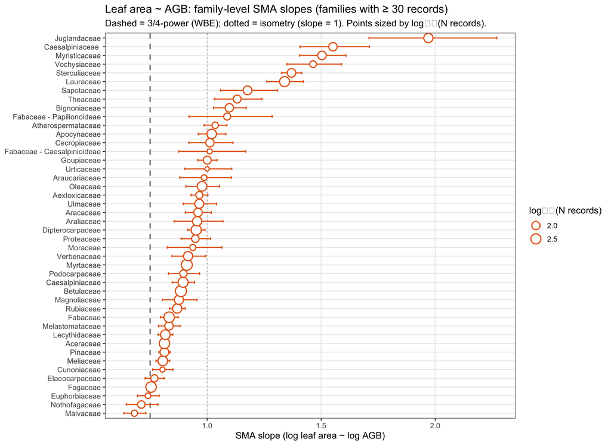

```r
fam_al_counts <- d_al %>%
  filter(!is.na(family)) %>%
  count(family) %>%
  filter(n >= MIN_N_FAM) %>%
  pull(family)

fam_al_slopes <- d_al %>%
  filter(!is.na(family), family %in% fam_al_counts) %>%
  group_by(family) %>%
  group_modify(~ {
    tryCatch({
      lx  <- log10(.x$m.to)
      ly  <- log10(.x$a.lf)
      fit <- sma(ly ~ lx)
      cm  <- fit$coef[[1]]
      data.frame(
        n         = nrow(.x),
        n_sp      = n_distinct(.x$speciesMatched),
        intercept = cm[1, 1],
        slope     = cm[2, 1],
        slope_lo  = cm[2, 2],
        slope_hi  = cm[2, 3],
        r2        = cor(lx, ly)^2
      )
    }, error = function(e) {
      data.frame(n = nrow(.x), n_sp = n_distinct(.x$speciesMatched),
                 intercept = NA, slope = NA, slope_lo = NA, slope_hi = NA, r2 = NA)
    })
  }) %>%
  ungroup() %>%
  filter(!is.na(slope)) %>%
  arrange(slope)

# OLS per family — leaf area
fam_al_ols <- d_al %>%
  filter(!is.na(family), family %in% fam_al_counts) %>%
  group_by(family) %>%
  group_modify(~ {
    tryCatch({
      fit <- lm(log10(.x$a.lf) ~ log10(.x$m.to))
      data.frame(ols_slope = round(coef(fit)[2], 3))
    }, error = function(e) data.frame(ols_slope = NA_real_))
  }) %>%
  ungroup()
fam_al_slopes <- fam_al_slopes %>% left_join(fam_al_ols, by = "family")

ggplot(fam_al_slopes, aes(x = slope, y = reorder(family, slope))) +
  geom_vline(xintercept = 0.75, colour = "grey50", linetype = "dashed", linewidth = 0.8) +
  geom_vline(xintercept = 1.00, colour = "grey70", linetype = "dotted", linewidth = 0.6) +
  geom_errorbarh(aes(xmin = slope_lo, xmax = slope_hi),
                 height = 0.3, colour = "#e5691f", linewidth = 0.7) +
  geom_point(aes(size = log10(n)), colour = "#e5691f", fill = "white", shape = 21,
             stroke = 1.1) +
  scale_size_continuous(range = c(2, 6), name = "log₁₀(N records)") +
  labs(
    x = "SMA slope (log leaf area ~ log AGB)",
    y = NULL,
    title = paste0("Leaf area ~ AGB: family-level SMA slopes (families with ≥ ", MIN_N_FAM, " records)"),
    subtitle = "Dashed = 3/4-power (WBE); dotted = isometry (slope = 1). Points sized by log₁₀(N records)."
  ) +
  theme(panel.grid.major.y = element_line(colour = "grey92"),
        panel.grid.minor   = element_blank())
```

```r
kable(
  fam_al_slopes %>%
    arrange(desc(n)) %>%
    mutate(across(c(slope, slope_lo, slope_hi, r2, intercept, ols_slope), ~ round(.x, 3))) %>%
    dplyr::select(family, n, n_sp, slope, slope_lo, slope_hi, ols_slope, r2),
  col.names = c("Family", "N records", "N species", "SMA slope",
                "SMA CI lo", "SMA CI hi", "OLS slope", "R²"),
  caption = paste0("Family-level SMA and OLS slopes — leaf area ~ AGB (≥ ", MIN_N_FAM, " records)")
)
```

Family-level SMA and OLS slopes — leaf area ~ AGB (≥ 30 records)

| Family | N records | N species | SMA slope | SMA CI lo | SMA CI hi | OLS slope | R² |
| --- | --- | --- | --- | --- | --- | --- | --- |
| Betulaceae | 775 | 6 | 0.885 | 0.872 | 0.899 | 0.865 | 0.954 |
| Myrtaceae | 677 | 11 | 0.911 | 0.894 | 0.928 | 0.883 | 0.940 |
| Fabaceae | 448 | 5 | 0.833 | 0.795 | 0.873 | 0.720 | 0.746 |
| Fagaceae | 444 | 6 | 0.754 | 0.732 | 0.777 | 0.714 | 0.896 |
| Aceraceae | 429 | 3 | 0.813 | 0.795 | 0.832 | 0.789 | 0.943 |
| Dipterocarpaceae | 373 | 20 | 0.952 | 0.915 | 0.991 | 0.877 | 0.849 |
| Lauraceae | 317 | 10 | 1.339 | 1.262 | 1.422 | 1.126 | 0.707 |
| Caesalpiniaceae | 315 | 3 | 0.895 | 0.847 | 0.945 | 0.779 | 0.759 |
| Meliaceae | 244 | 5 | 0.805 | 0.776 | 0.836 | 0.769 | 0.911 |
| Lecythidaceae | 236 | 4 | 0.817 | 0.785 | 0.849 | 0.777 | 0.906 |
| Oleaceae | 227 | 3 | 0.977 | 0.907 | 1.054 | 0.803 | 0.674 |
| Apocynaceae | 217 | 4 | 1.020 | 0.961 | 1.082 | 0.914 | 0.804 |
| Rubiaceae | 184 | 20 | 0.869 | 0.835 | 0.904 | 0.836 | 0.926 |
| Juglandaceae | 184 | 1 | 1.970 | 1.710 | 2.270 | 0.466 | 0.056 |
| Araliaceae | 182 | 4 | 0.956 | 0.855 | 1.069 | 0.619 | 0.419 |
| Magnoliaceae | 175 | 3 | 0.876 | 0.803 | 0.955 | 0.715 | 0.665 |
| Verbenaceae | 173 | 3 | 0.916 | 0.846 | 0.993 | 0.775 | 0.716 |
| Ulmaceae | 161 | 5 | 0.965 | 0.895 | 1.041 | 0.845 | 0.767 |
| Sapotaceae | 133 | 3 | 1.177 | 1.059 | 1.309 | 0.929 | 0.623 |
| Pinaceae | 129 | 2 | 0.813 | 0.789 | 0.837 | 0.801 | 0.971 |
| Sterculiaceae | 119 | 1 | 1.370 | 1.326 | 1.415 | 1.348 | 0.968 |
| Myristicaceae | 118 | 1 | 1.503 | 1.405 | 1.609 | 1.398 | 0.865 |
| Aracaceae | 113 | 1 | 0.960 | 0.905 | 1.018 | 0.911 | 0.901 |
| Melastomataceae | 111 | 2 | 0.833 | 0.787 | 0.881 | 0.795 | 0.911 |
| Bignoniaceae | 111 | 2 | 1.097 | 1.028 | 1.171 | 1.031 | 0.882 |
| Caesalpiniaceae | 111 | 1 | 1.552 | 1.407 | 1.711 | 1.329 | 0.734 |
| Cecropiaceae | 107 | 1 | 1.012 | 0.920 | 1.113 | 0.880 | 0.756 |
| Goupiaceae | 88 | 1 | 1.000 | 0.959 | 1.044 | 0.981 | 0.961 |
| Theaceae | 86 | 5 | 1.132 | 1.032 | 1.240 | 1.025 | 0.821 |
| Nothofagaceae | 72 | 5 | 0.712 | 0.645 | 0.784 | 0.649 | 0.833 |
| Proteaceae | 71 | 4 | 0.948 | 0.886 | 1.015 | 0.909 | 0.920 |
| Podocarpaceae | 68 | 5 | 0.896 | 0.830 | 0.967 | 0.851 | 0.903 |
| Elaeocarpaceae | 65 | 2 | 0.768 | 0.728 | 0.811 | 0.750 | 0.953 |
| Aextoxicaceae | 61 | 1 | 0.966 | 0.929 | 1.003 | 0.955 | 0.978 |
| Fabaceae - Papilionoideae | 60 | 4 | 1.088 | 0.921 | 1.285 | 0.839 | 0.594 |
| Vochysiaceae | 55 | 1 | 1.465 | 1.350 | 1.589 | 1.399 | 0.912 |
| Atherospermataceae | 51 | 2 | 1.035 | 0.986 | 1.086 | 1.020 | 0.972 |
| Malvaceae | 48 | 2 | 0.681 | 0.634 | 0.731 | 0.661 | 0.942 |
| Moraceae | 46 | 5 | 0.937 | 0.825 | 1.066 | 0.849 | 0.821 |
| Araucariaceae | 43 | 2 | 0.987 | 0.880 | 1.106 | 0.919 | 0.868 |
| Euphorbiaceae | 42 | 4 | 0.741 | 0.695 | 0.790 | 0.726 | 0.960 |
| Cunoniaceae | 40 | 3 | 0.804 | 0.761 | 0.850 | 0.792 | 0.971 |
| Fabaceae - Caesalpinioideae | 40 | 4 | 1.011 | 0.875 | 1.169 | 0.907 | 0.804 |
| Urticaceae | 39 | 4 | 1.000 | 0.902 | 1.108 | 0.951 | 0.904 |

# 6 Intraspecific scaling

**Interpretation caveat:** BAAD individuals within a species often come from a single study or a narrow size range. Intraspecific slopes should be treated as within-study estimates and may reflect ontogenetic or site-level effects rather than true species-level allometries.

## 6.1 Leaf mass ~ AGB: intraspecific slope distribution

```r
MIN_N_INTRA <- 8

intra_lf <- d_lf %>%
  filter(!is.na(speciesMatched)) %>%
  group_by(speciesMatched) %>%
  group_modify(~ {
    if (nrow(.x) < MIN_N_INTRA) return(data.frame())
    tryCatch({
      lx   <- log10(.x$m.to)
      ly   <- log10(.x$m.lf)
      fit  <- sma(ly ~ lx)
      cm   <- fit$coef[[1]]
      data.frame(
        n         = nrow(.x),
        family    = .x$family[1],
        clade     = .x$clade[1],
        slope     = cm[2, 1],
        slope_lo  = cm[2, 2],
        slope_hi  = cm[2, 3],
        ols_slope = unname(coef(lm(ly ~ lx))[2]),
        r2        = cor(lx, ly)^2,
        agb_range = diff(range(lx))
      )
    }, error = function(e) data.frame())
  }) %>%
  ungroup()

cat("Species with ≥", MIN_N_INTRA, "records (m.lf + m.to):", nrow(intra_lf), "\n")
```

```
## Species with ≥ 8 records (m.lf + m.to): 187
```

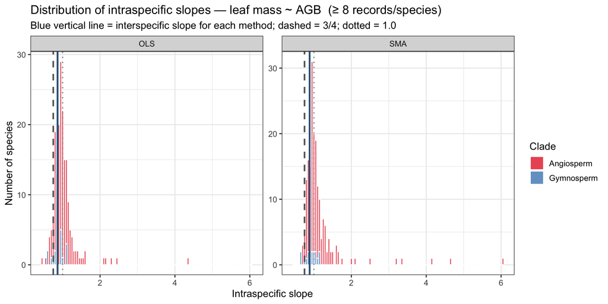

```r
# Pivot to long format so OLS and SMA histograms appear side by side
intra_lf_long <- intra_lf %>%
  tidyr::pivot_longer(cols = c(slope, ols_slope),
                      names_to = "method", values_to = "est_slope") %>%
  dplyr::mutate(method = dplyr::recode(method, slope = "SMA", ols_slope = "OLS")) %>%
  dplyr::filter(is.finite(est_slope))

# Per-method interspecific reference lines (match facet panels)
vline_lf <- data.frame(
  method  = c("SMA", "OLS"),
  xint_sp = c(sl_lf, ols_sl_lf)
)

ggplot(intra_lf_long, aes(x = est_slope, fill = clade)) +
  geom_histogram(binwidth = 0.05, colour = "white", alpha = 0.75, position = "stack") +
  geom_vline(data = vline_lf, aes(xintercept = xint_sp),
             linetype = "solid", colour = "steelblue4", linewidth = 1) +
  geom_vline(xintercept = 0.75, linetype = "dashed", colour = "grey40", linewidth = 0.9) +
  geom_vline(xintercept = 1.00, linetype = "dotted", colour = "grey60", linewidth = 0.7) +
  scale_fill_manual(values = c(Angiosperm = "#e41a1c", Gymnosperm = "#377eb8"),
                    na.value = "grey60", name = "Clade") +
  facet_wrap(~ method, ncol = 2, scales = "free_y") +
  labs(
    x = "Intraspecific slope",
    y = "Number of species",
    title = paste0("Distribution of intraspecific slopes — leaf mass ~ AGB  (≥ ", MIN_N_INTRA, " records/species)"),
    subtitle = "Blue vertical line = interspecific slope for each method; dashed = 3/4; dotted = 1.0"
  )
```

```r
kable(
  intra_lf %>%
    group_by(clade) %>%
    summarise(
      n_species   = n(),
      median_slope = round(median(slope, na.rm = TRUE), 3),
      mean_slope   = round(mean(slope, na.rm = TRUE), 3),
      sd_slope     = round(sd(slope, na.rm = TRUE), 3),
      pct_lt_075   = round(mean(slope < 0.75, na.rm = TRUE) * 100, 1),
      pct_gt_1     = round(mean(slope > 1.00, na.rm = TRUE) * 100, 1)
    ),
  col.names = c("Clade", "N species", "Median slope", "Mean slope", "SD slope",
                "% slopes < 0.75", "% slopes > 1.0"),
  caption = "Summary of intraspecific leaf mass ~ AGB slopes by clade"
)
```

Summary of intraspecific leaf mass ~ AGB slopes by clade

| Clade | N species | Median slope | Mean slope | SD slope | % slopes < 0.75 | % slopes > 1.0 |
| --- | --- | --- | --- | --- | --- | --- |
| Angiosperm | 171 | 1.007 | 1.155 | 0.626 | 2.9 | 53.8 |
| Gymnosperm | 16 | 0.957 | 0.923 | 0.164 | 18.8 | 37.5 |

## 6.2 Top species by record count — leaf mass ~ AGB

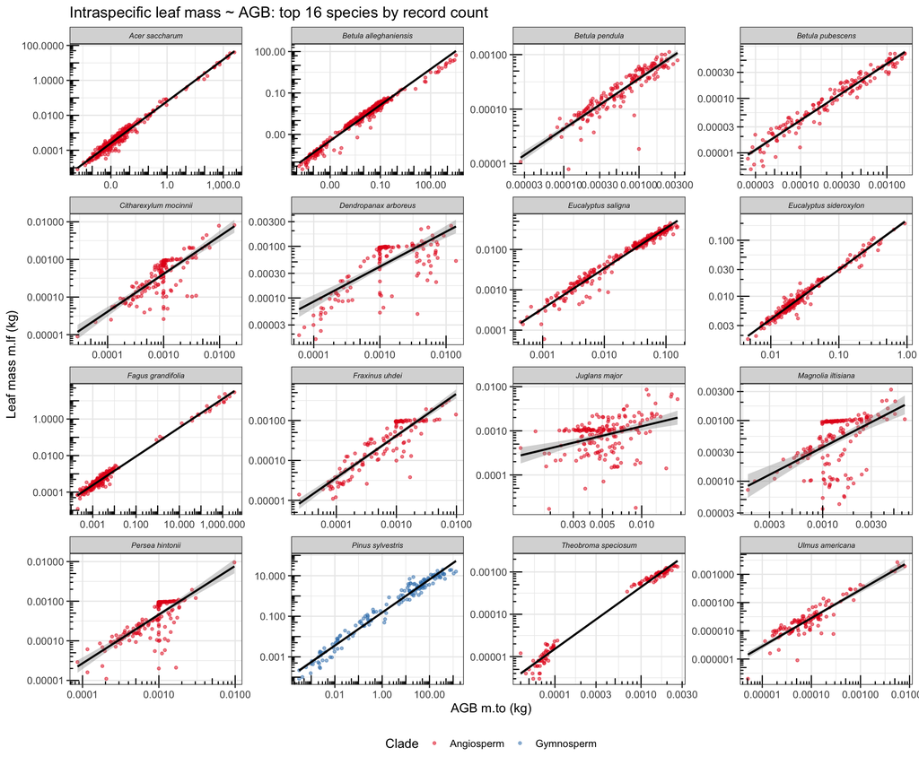

```r
top_sp_lf <- intra_lf %>%
  arrange(desc(n)) %>%
  slice_head(n = 16) %>%
  pull(speciesMatched)

d_lf %>%
  filter(speciesMatched %in% top_sp_lf) %>%
  ggplot(aes(x = m.to, y = m.lf)) +
  geom_point(aes(colour = clade), alpha = 0.5, size = 1) +
  geom_smooth(method = "lm", formula = y ~ x,   # lm on log scale = SMA direction visual
              colour = "black", se = TRUE, linewidth = 0.9) +
  scale_x_log10(labels = comma) +
  scale_y_log10(labels = comma) +
  scale_colour_manual(values = c(Angiosperm = "#e41a1c", Gymnosperm = "#377eb8"),
                      na.value = "grey60") +
  facet_wrap(~ speciesMatched, scales = "free", ncol = 4) +
  annotation_logticks() +
  labs(
    x = "AGB m.to (kg)", y = "Leaf mass m.lf (kg)", colour = "Clade",
    title = "Intraspecific leaf mass ~ AGB: top 16 species by record count"
  ) +
  theme(strip.text = element_text(size = 7, face = "italic"),
        legend.position = "bottom")
```

## 6.3 Leaf area ~ AGB: intraspecific slope distribution

```r
intra_al <- d_al %>%
  filter(!is.na(speciesMatched)) %>%
  group_by(speciesMatched) %>%
  group_modify(~ {
    if (nrow(.x) < MIN_N_INTRA) return(data.frame())
    tryCatch({
      lx   <- log10(.x$m.to)
      ly   <- log10(.x$a.lf)
      fit  <- sma(ly ~ lx)
      cm   <- fit$coef[[1]]
      data.frame(
        n         = nrow(.x),
        family    = .x$family[1],
        clade     = .x$clade[1],
        slope     = cm[2, 1],
        slope_lo  = cm[2, 2],
        slope_hi  = cm[2, 3],
        ols_slope = unname(coef(lm(ly ~ lx))[2]),
        r2        = cor(lx, ly)^2,
        agb_range = diff(range(lx))
      )
    }, error = function(e) data.frame())
  }) %>%
  ungroup()

cat("Species with ≥", MIN_N_INTRA, "records (a.lf + m.to):", nrow(intra_al), "\n")
```

```
## Species with ≥ 8 records (a.lf + m.to): 170
```

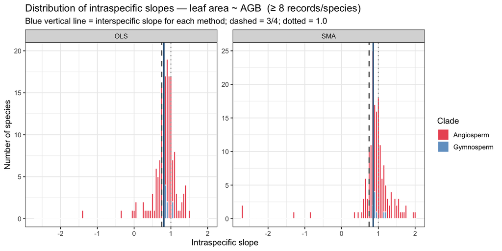

```r
# Pivot to long format so OLS and SMA histograms appear side by side
intra_al_long <- intra_al %>%
  tidyr::pivot_longer(cols = c(slope, ols_slope),
                      names_to = "method", values_to = "est_slope") %>%
  dplyr::mutate(method = dplyr::recode(method, slope = "SMA", ols_slope = "OLS")) %>%
  dplyr::filter(is.finite(est_slope))

vline_al <- data.frame(
  method  = c("SMA", "OLS"),
  xint_sp = c(sl_al, ols_sl_al)
)

ggplot(intra_al_long, aes(x = est_slope, fill = clade)) +
  geom_histogram(binwidth = 0.05, colour = "white", alpha = 0.75, position = "stack") +
  geom_vline(data = vline_al, aes(xintercept = xint_sp),
             linetype = "solid", colour = "steelblue4", linewidth = 1) +
  geom_vline(xintercept = 0.75, linetype = "dashed", colour = "grey40", linewidth = 0.9) +
  geom_vline(xintercept = 1.00, linetype = "dotted", colour = "grey60", linewidth = 0.7) +
  scale_fill_manual(values = c(Angiosperm = "#e41a1c", Gymnosperm = "#377eb8"),
                    na.value = "grey60", name = "Clade") +
  facet_wrap(~ method, ncol = 2, scales = "free_y") +
  labs(
    x = "Intraspecific slope",
    y = "Number of species",
    title = paste0("Distribution of intraspecific slopes — leaf area ~ AGB  (≥ ", MIN_N_INTRA, " records/species)"),
    subtitle = "Blue vertical line = interspecific slope for each method; dashed = 3/4; dotted = 1.0"
  )
```

```r
kable(
  intra_al %>%
    group_by(clade) %>%
    summarise(
      n_species   = n(),
      median_slope = round(median(slope, na.rm = TRUE), 3),
      mean_slope   = round(mean(slope, na.rm = TRUE), 3),
      sd_slope     = round(sd(slope, na.rm = TRUE), 3),
      pct_lt_075   = round(mean(slope < 0.75, na.rm = TRUE) * 100, 1),
      pct_gt_1     = round(mean(slope > 1.00, na.rm = TRUE) * 100, 1)
    ),
  col.names = c("Clade", "N species", "Median slope", "Mean slope", "SD slope",
                "% slopes < 0.75", "% slopes > 1.0"),
  caption = "Summary of intraspecific leaf area ~ AGB slopes by clade"
)
```

Summary of intraspecific leaf area ~ AGB slopes by clade

| Clade | N species | Median slope | Mean slope | SD slope | % slopes < 0.75 | % slopes > 1.0 |
| --- | --- | --- | --- | --- | --- | --- |
| Angiosperm | 161 | 0.946 | 0.922 | 0.541 | 13 | 39.1 |
| Gymnosperm | 9 | 0.888 | 0.945 | 0.127 | 0 | 22.2 |

## 6.4 Top species by record count — leaf area ~ AGB

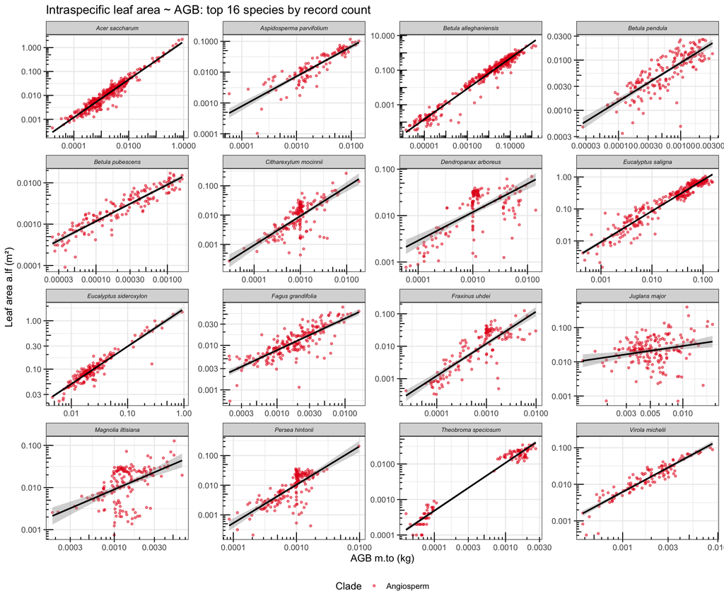

```r
top_sp_al <- intra_al %>%
  arrange(desc(n)) %>%
  slice_head(n = 16) %>%
  pull(speciesMatched)

d_al %>%
  filter(speciesMatched %in% top_sp_al) %>%
  ggplot(aes(x = m.to, y = a.lf)) +
  geom_point(aes(colour = clade), alpha = 0.5, size = 1) +
  geom_smooth(method = "lm", formula = y ~ x,
              colour = "black", se = TRUE, linewidth = 0.9) +
  scale_x_log10(labels = comma) +
  scale_y_log10(labels = comma) +
  scale_colour_manual(values = c(Angiosperm = "#e41a1c", Gymnosperm = "#377eb8"),
                      na.value = "grey60") +
  facet_wrap(~ speciesMatched, scales = "free", ncol = 4) +
  annotation_logticks() +
  labs(
    x = "AGB m.to (kg)", y = "Leaf area a.lf (m²)", colour = "Clade",
    title = "Intraspecific leaf area ~ AGB: top 16 species by record count"
  ) +
  theme(strip.text = element_text(size = 7, face = "italic"),
        legend.position = "bottom")
```

# 7 Intraspecific vs. interspecific slopes

A key question in allometry is whether slopes measured within species (ontogenetic or population-level variation) match those estimated across species (evolutionary divergence). The scatter below plots intraspecific SMA slope against the log₁₀ of sample size within each species.

## 7.1 Leaf mass ~ AGB

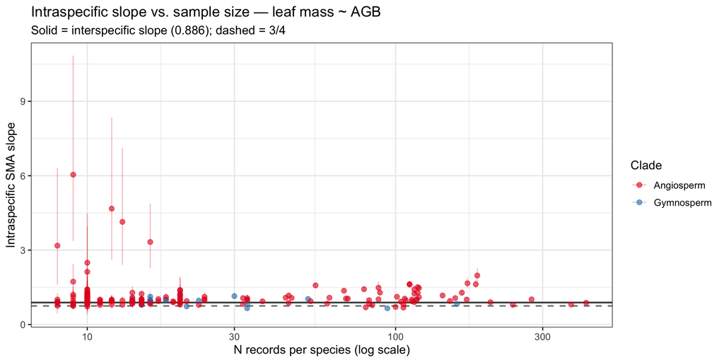

```r
ggplot(intra_lf, aes(x = n, y = slope, colour = clade)) +
  geom_hline(yintercept = sl_lf,  linetype = "solid",  colour = "grey30", linewidth = 0.8) +
  geom_hline(yintercept = 0.75,   linetype = "dashed", colour = "grey50", linewidth = 0.7) +
  geom_point(alpha = 0.6, size = 2) +
  geom_errorbar(aes(ymin = slope_lo, ymax = slope_hi), width = 0, alpha = 0.25) +
  scale_x_log10() +
  scale_colour_manual(values = c(Angiosperm = "#e41a1c", Gymnosperm = "#377eb8"),
                      na.value = "grey60") +
  labs(
    x = "N records per species (log scale)",
    y = "Intraspecific SMA slope",
    colour = "Clade",
    title = "Intraspecific slope vs. sample size — leaf mass ~ AGB",
    subtitle = paste0("Solid = interspecific slope (", sl_lf, "); dashed = 3/4")
  )
```

## 7.2 Leaf area ~ AGB

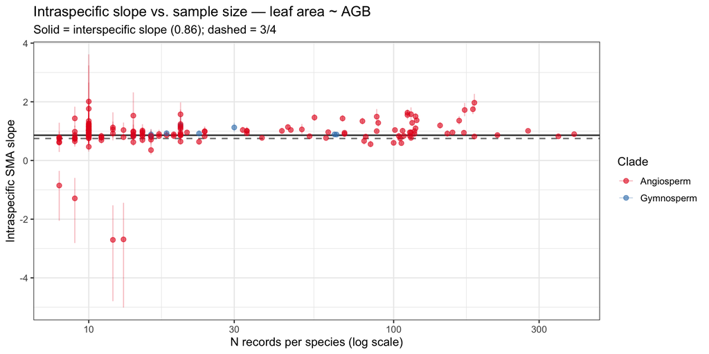

```r
ggplot(intra_al, aes(x = n, y = slope, colour = clade)) +
  geom_hline(yintercept = sl_al,  linetype = "solid",  colour = "grey30", linewidth = 0.8) +
  geom_hline(yintercept = 0.75,   linetype = "dashed", colour = "grey50", linewidth = 0.7) +
  geom_point(alpha = 0.6, size = 2) +
  geom_errorbar(aes(ymin = slope_lo, ymax = slope_hi), width = 0, alpha = 0.25) +
  scale_x_log10() +
  scale_colour_manual(values = c(Angiosperm = "#e41a1c", Gymnosperm = "#377eb8"),
                      na.value = "grey60") +
  labs(
    x = "N records per species (log scale)",
    y = "Intraspecific SMA slope",
    colour = "Clade",
    title = "Intraspecific slope vs. sample size — leaf area ~ AGB",
    subtitle = paste0("Solid = interspecific slope (", sl_al, "); dashed = 3/4")
  )
```

# 8 Summary table

```r
kable(data.frame(
  Relationship        = c("Leaf mass ~ AGB (all)",
                           "Leaf mass ~ AGB (Angiosperm)",
                           "Leaf mass ~ AGB (Gymnosperm)",
                           "Leaf area ~ AGB (all)",
                           "Leaf area ~ AGB (Angiosperm)",
                           "Leaf area ~ AGB (Gymnosperm)"),
  N                   = c(nrow(d_lf),
                           clade_lf$n[clade_lf$clade == "Angiosperm"],
                           clade_lf$n[clade_lf$clade == "Gymnosperm"],
                           nrow(d_al),
                           clade_al$n[clade_al$clade == "Angiosperm"],
                           clade_al$n[clade_al$clade == "Gymnosperm"]),
  SMA_slope           = round(c(sl_lf,
                                 clade_lf$slope[clade_lf$clade == "Angiosperm"],
                                 clade_lf$slope[clade_lf$clade == "Gymnosperm"],
                                 sl_al,
                                 clade_al$slope[clade_al$clade == "Angiosperm"],
                                 clade_al$slope[clade_al$clade == "Gymnosperm"]), 3),
  CI_lo               = round(c(fit_lf$coef[[1]][2, 2],
                                 clade_lf$slope_lo[clade_lf$clade == "Angiosperm"],
                                 clade_lf$slope_lo[clade_lf$clade == "Gymnosperm"],
                                 fit_al$coef[[1]][2, 2],
                                 clade_al$slope_lo[clade_al$clade == "Angiosperm"],
                                 clade_al$slope_lo[clade_al$clade == "Gymnosperm"]), 3),
  CI_hi               = round(c(fit_lf$coef[[1]][2, 3],
                                 clade_lf$slope_hi[clade_lf$clade == "Angiosperm"],
                                 clade_lf$slope_hi[clade_lf$clade == "Gymnosperm"],
                                 fit_al$coef[[1]][2, 3],
                                 clade_al$slope_hi[clade_al$clade == "Angiosperm"],
                                 clade_al$slope_hi[clade_al$clade == "Gymnosperm"]), 3),
  OLS_slope           = round(c(ols_sl_lf,
                                 clade_lf$ols_slope[clade_lf$clade == "Angiosperm"],
                                 clade_lf$ols_slope[clade_lf$clade == "Gymnosperm"],
                                 ols_sl_al,
                                 clade_al$ols_slope[clade_al$clade == "Angiosperm"],
                                 clade_al$ols_slope[clade_al$clade == "Gymnosperm"]), 3),
  PGLS_slope          = c(if (!is.null(pgls_lf_result)) pgls_lf_result$slope else NA,
                           NA, NA,
                           if (!is.null(pgls_al_result)) pgls_al_result$slope else NA,
                           NA, NA),
  R2                  = round(c(r2_lf,
                                 clade_lf$r2[clade_lf$clade == "Angiosperm"],
                                 clade_lf$r2[clade_lf$clade == "Gymnosperm"],
                                 r2_al,
                                 clade_al$r2[clade_al$clade == "Angiosperm"],
                                 clade_al$r2[clade_al$clade == "Gymnosperm"]), 3)
),
col.names = c("Relationship", "N records", "SMA slope", "SMA CI lo", "SMA CI hi",
              "OLS slope", "PGLS slope", "R²"),
caption = "Summary of interspecific slopes by method (all and by clade); PGLS on species means only")
```

Summary of interspecific slopes by method (all and by clade); PGLS on species means only

| Relationship | N records | SMA slope | SMA CI lo | SMA CI hi | OLS slope | PGLS slope | R² |
| --- | --- | --- | --- | --- | --- | --- | --- |
| Leaf mass ~ AGB (all) | 8854 | 0.886 | 0.882 | 0.890 | 0.865 | NA | 0.953 |
| Leaf mass ~ AGB (Angiosperm) | 8277 | 0.884 | 0.879 | 0.889 | 0.855 | NA | 0.935 |
| Leaf mass ~ AGB (Gymnosperm) | 577 | 0.877 | 0.866 | 0.888 | 0.867 | NA | 0.977 |
| Leaf area ~ AGB (all) | 8198 | 0.860 | 0.853 | 0.866 | 0.809 | NA | 0.886 |
| Leaf area ~ AGB (Angiosperm) | 7923 | 0.873 | 0.867 | 0.880 | 0.818 | NA | 0.876 |
| Leaf area ~ AGB (Gymnosperm) | 275 | 0.862 | 0.848 | 0.877 | 0.854 | NA | 0.980 |

# 9 Stem biomass vs. leaf mass and leaf area

Stem biomass (`m.st`, kg) is the woody stem mass recorded in BAAD, excluding leaves and typically representing the main structural axis. Using `m.st` rather than total above-ground biomass (`m.to`) as the predictor removes the circular dependency between leaf investment and the response variable — `m.to` includes `m.lf`, so any regression of `m.lf ~ m.to` is partly self-referential. Stem biomass is a cleaner structural predictor.

```r
kable(data.frame(
  Dataset    = c("m.lf ~ m.st", "a.lf ~ m.st"),
  N_records  = c(nrow(d_st_lf), nrow(d_st_al)),
  N_species  = c(n_distinct(d_st_lf$speciesMatched), n_distinct(d_st_al$speciesMatched)),
  N_families = c(n_distinct(d_st_lf$family[!is.na(d_st_lf$family)]),
                 n_distinct(d_st_al$family[!is.na(d_st_al$family)]))
), caption = "Record counts for stem biomass scaling analyses")
```

Record counts for stem biomass scaling analyses

| Dataset | N_records | N_species | N_families |
| --- | --- | --- | --- |
| m.lf ~ m.st | 14220 | 535 | 113 |
| a.lf ~ m.st | 11429 | 403 | 97 |

## 9.1 Leaf mass ~ stem biomass

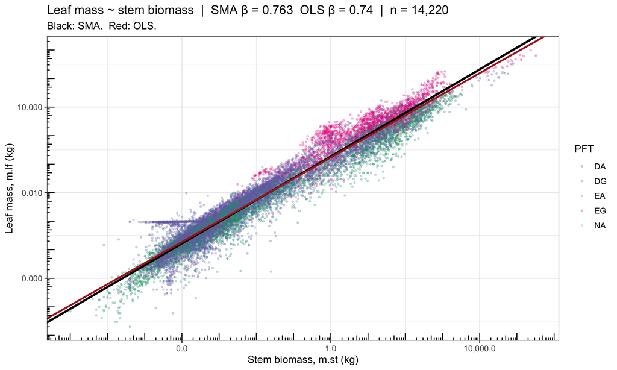

```r
fit_st_lf     <- sma(log10(m.lf) ~ log10(m.st), data = d_st_lf)
sl_st_lf      <- round(coef(fit_st_lf)[2], 3)
int_st_lf     <- round(coef(fit_st_lf)[1], 3)
r2_st_lf      <- round(cor(log10(d_st_lf$m.lf), log10(d_st_lf$m.st))^2, 3)

lm_st_lf      <- lm(log10(m.lf) ~ log10(m.st), data = d_st_lf)
ols_sl_st_lf  <- round(coef(lm_st_lf)[2], 3)
ols_int_st_lf <- round(coef(lm_st_lf)[1], 3)
ols_ci_st_lf  <- round(confint(lm_st_lf)[2, ], 3)
ols_r2_st_lf  <- round(summary(lm_st_lf)$r.squared, 3)

ggplot(d_st_lf, aes(x = m.st, y = m.lf, colour = pft)) +
  geom_point(alpha = 0.25, size = 0.7) +
  geom_abline(intercept = int_st_lf, slope = sl_st_lf,
              colour = "black", linewidth = 1.2) +
  geom_abline(intercept = ols_int_st_lf, slope = ols_sl_st_lf,
              colour = "firebrick", linewidth = 1.0) +
  scale_x_log10(labels = comma) +
  scale_y_log10(labels = comma) +
  scale_colour_brewer(palette = "Dark2", na.value = "grey70") +
  annotation_logticks() +
  labs(
    x = "Stem biomass, m.st (kg)",
    y = "Leaf mass, m.lf (kg)",
    colour = "PFT",
    title = paste0("Leaf mass ~ stem biomass  |  SMA \u03b2 = ", sl_st_lf,
                   "  OLS \u03b2 = ", ols_sl_st_lf,
                   "  |  n = ", format(nrow(d_st_lf), big.mark = ",")),
    subtitle = "Black: SMA.  Red: OLS."
  )
```

```r
kable(data.frame(
  Method = c("OLS", "SMA"),
  Slope  = c(ols_sl_st_lf, sl_st_lf),
  CI_lo  = c(ols_ci_st_lf[1], round(fit_st_lf$coef[[1]][2, 2], 3)),
  CI_hi  = c(ols_ci_st_lf[2], round(fit_st_lf$coef[[1]][2, 3], 3)),
  R2     = c(ols_r2_st_lf, r2_st_lf)
),
col.names = c("Method", "Slope", "95% CI lo", "95% CI hi", "R\u00b2"),
caption = "OLS vs. SMA \u2014 leaf mass ~ stem biomass")
```

OLS vs. SMA — leaf mass ~ stem biomass

|  | Method | Slope | 95% CI lo | 95% CI hi | R² |
| --- | --- | --- | --- | --- | --- |
| log10(m.st) | OLS | 0.740 | 0.737 | 0.743 | 0.942 |
| slope | SMA | 0.763 | 0.760 | 0.766 | 0.942 |

## 9.2 Leaf area ~ stem biomass

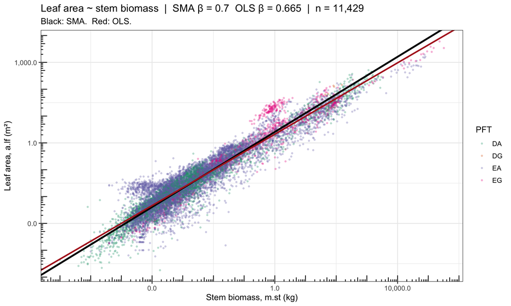

```r
fit_st_al     <- sma(log10(a.lf) ~ log10(m.st), data = d_st_al)
sl_st_al      <- round(coef(fit_st_al)[2], 3)
int_st_al     <- round(coef(fit_st_al)[1], 3)
r2_st_al      <- round(cor(log10(d_st_al$a.lf), log10(d_st_al$m.st))^2, 3)

lm_st_al      <- lm(log10(a.lf) ~ log10(m.st), data = d_st_al)
ols_sl_st_al  <- round(coef(lm_st_al)[2], 3)
ols_int_st_al <- round(coef(lm_st_al)[1], 3)
ols_ci_st_al  <- round(confint(lm_st_al)[2, ], 3)
ols_r2_st_al  <- round(summary(lm_st_al)$r.squared, 3)

ggplot(d_st_al, aes(x = m.st, y = a.lf, colour = pft)) +
  geom_point(alpha = 0.25, size = 0.7) +
  geom_abline(intercept = int_st_al, slope = sl_st_al,
              colour = "black", linewidth = 1.2) +
  geom_abline(intercept = ols_int_st_al, slope = ols_sl_st_al,
              colour = "firebrick", linewidth = 1.0) +
  scale_x_log10(labels = comma) +
  scale_y_log10(labels = comma) +
  scale_colour_brewer(palette = "Dark2", na.value = "grey70") +
  annotation_logticks() +
  labs(
    x = "Stem biomass, m.st (kg)",
    y = "Leaf area, a.lf (m\u00b2)",
    colour = "PFT",
    title = paste0("Leaf area ~ stem biomass  |  SMA \u03b2 = ", sl_st_al,
                   "  OLS \u03b2 = ", ols_sl_st_al,
                   "  |  n = ", format(nrow(d_st_al), big.mark = ",")),
    subtitle = "Black: SMA.  Red: OLS."
  )
```

```r
kable(data.frame(
  Method = c("OLS", "SMA"),
  Slope  = c(ols_sl_st_al, sl_st_al),
  CI_lo  = c(ols_ci_st_al[1], round(fit_st_al$coef[[1]][2, 2], 3)),
  CI_hi  = c(ols_ci_st_al[2], round(fit_st_al$coef[[1]][2, 3], 3)),
  R2     = c(ols_r2_st_al, r2_st_al)
),
col.names = c("Method", "Slope", "95% CI lo", "95% CI hi", "R\u00b2"),
caption = "OLS vs. SMA \u2014 leaf area ~ stem biomass")
```

OLS vs. SMA — leaf area ~ stem biomass

|  | Method | Slope | 95% CI lo | 95% CI hi | R² |
| --- | --- | --- | --- | --- | --- |
| log10(m.st) | OLS | 0.665 | 0.661 | 0.669 | 0.903 |
| slope | SMA | 0.700 | 0.696 | 0.704 | 0.903 |

## 9.3 Angiosperm vs. Gymnosperm — stem biomass scaling

```r
stem_clade_results <- bind_rows(lapply(c("Angiosperm", "Gymnosperm"), function(cl) {
  bind_rows(lapply(list(
    list(df = d_st_lf, ycol = "m.lf", ylabel = "Leaf mass"),
    list(df = d_st_al, ycol = "a.lf", ylabel = "Leaf area")
  ), function(item) {
    sub_df <- item$df %>% filter(!is.na(clade), clade == cl)
    if (nrow(sub_df) < 5) return(NULL)
    tryCatch({
      lx  <- log10(sub_df$m.st)
      ly  <- log10(sub_df[[item$ycol]])
      fit <- sma(ly ~ lx)
      lmf <- lm(ly ~ lx)
      data.frame(
        Clade     = cl,
        Response  = item$ylabel,
        N         = nrow(sub_df),
        SMA_slope = round(fit$coef[[1]][2, 1], 3),
        OLS_slope = round(coef(lmf)[2], 3),
        R2        = round(cor(lx, ly)^2, 3)
      )
    }, error = function(e) NULL)
  }))
}))

kable(stem_clade_results,
      col.names = c("Clade", "Response", "N", "SMA slope", "OLS slope", "R\u00b2"),
      caption = "SMA and OLS slopes for leaf traits ~ stem biomass by clade")
```

SMA and OLS slopes for leaf traits ~ stem biomass by clade

|  | Clade | Response | N | SMA slope | OLS slope | R² |
| --- | --- | --- | --- | --- | --- | --- |
| lx…1 | Angiosperm | Leaf mass | 12206 | 0.735 | 0.711 | 0.935 |
| lx…2 | Angiosperm | Leaf area | 10494 | 0.690 | 0.652 | 0.893 |
| lx…3 | Gymnosperm | Leaf mass | 2008 | 0.770 | 0.741 | 0.926 |
| lx…4 | Gymnosperm | Leaf area | 935 | 0.766 | 0.727 | 0.901 |

## 9.4 Intraspecific slopes — stem biomass scaling

```r
MIN_N_ST <- 8

make_stem_intra <- function(df, ycol) {
  df %>%
    filter(!is.na(speciesMatched)) %>%
    group_by(speciesMatched) %>%
    group_modify(~ {
      if (nrow(.x) < MIN_N_ST) return(data.frame())
      tryCatch({
        lx      <- log10(.x$m.st)
        ly      <- log10(.x[[ycol]])
        fit     <- sma(ly ~ lx)
        cm      <- fit$coef[[1]]
        lm_fit  <- lm(ly ~ lx)
        lm_ci   <- confint(lm_fit)
        data.frame(
          n         = nrow(.x),
          clade     = .x$clade[1],
          slope     = cm[2, 1],
          sma_ci_lo = cm[2, 2],
          sma_ci_hi = cm[2, 3],
          ols_slope = unname(coef(lm_fit)[2]),
          ols_ci_lo = lm_ci[2, 1],
          ols_ci_hi = lm_ci[2, 2],
          st_range  = diff(range(lx))
        )
      }, error = function(e) data.frame())
    }) %>%
    ungroup()
}

intra_st_lf <- make_stem_intra(d_st_lf, "m.lf")
intra_st_al <- make_stem_intra(d_st_al, "a.lf")

cat("Leaf mass ~ stem: species with \u2265", MIN_N_ST, "records:", nrow(intra_st_lf), "\n")
```

```
## Leaf mass ~ stem: species with ≥ 8 records: 322
```

```r
cat("Leaf area ~ stem: species with \u2265", MIN_N_ST, "records:", nrow(intra_st_al), "\n")
```

```
## Leaf area ~ stem: species with ≥ 8 records: 268
```

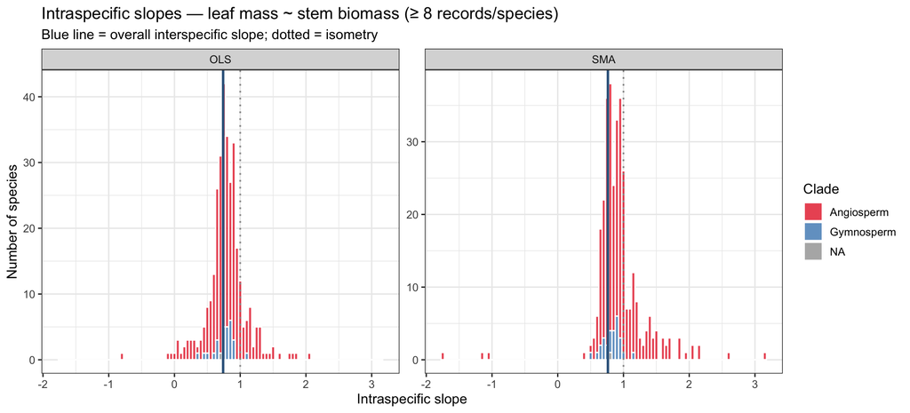

```r
plot_stem_hist <- function(intra_df, ref_sma, ref_ols, trait_label) {
  if (nrow(intra_df) == 0) { cat("No eligible species for", trait_label, "\n"); return(invisible(NULL)) }
  long <- intra_df %>%
    tidyr::pivot_longer(cols = c(slope, ols_slope),
                        names_to = "method", values_to = "est_slope") %>%
    dplyr::mutate(method = dplyr::recode(method, slope = "SMA", ols_slope = "OLS")) %>%
    dplyr::filter(is.finite(est_slope))
  vlines <- data.frame(method = c("SMA","OLS"), xint_sp = c(ref_sma, ref_ols))
  ggplot(long, aes(x = est_slope, fill = clade)) +
    geom_histogram(binwidth = 0.05, colour = "white", alpha = 0.75, position = "stack") +
    geom_vline(data = vlines, aes(xintercept = xint_sp),
               linetype = "solid", colour = "steelblue4", linewidth = 1) +
    geom_vline(xintercept = 1.00, linetype = "dotted", colour = "grey60", linewidth = 0.7) +
    scale_fill_manual(values = c(Angiosperm = "#e41a1c", Gymnosperm = "#377eb8"),
                      na.value = "grey60", name = "Clade") +
    facet_wrap(~ method, ncol = 2, scales = "free_y") +
    labs(
      x = "Intraspecific slope",
      y = "Number of species",
      title = paste0("Intraspecific slopes \u2014 ", trait_label, " ~ stem biomass (\u2265 ", MIN_N_ST, " records/species)"),
      subtitle = "Blue line = overall interspecific slope; dotted = isometry"
    )
}

print(plot_stem_hist(intra_st_lf, sl_st_lf, ols_sl_st_lf, "leaf mass"))
```

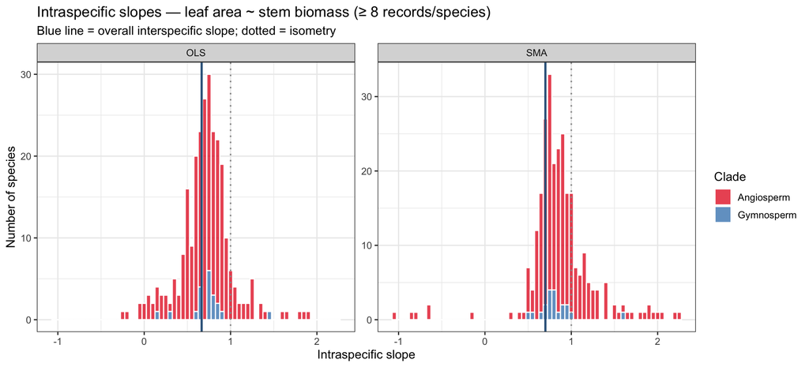

```r
print(plot_stem_hist(intra_st_al, sl_st_al, ols_sl_st_al, "leaf area"))
```

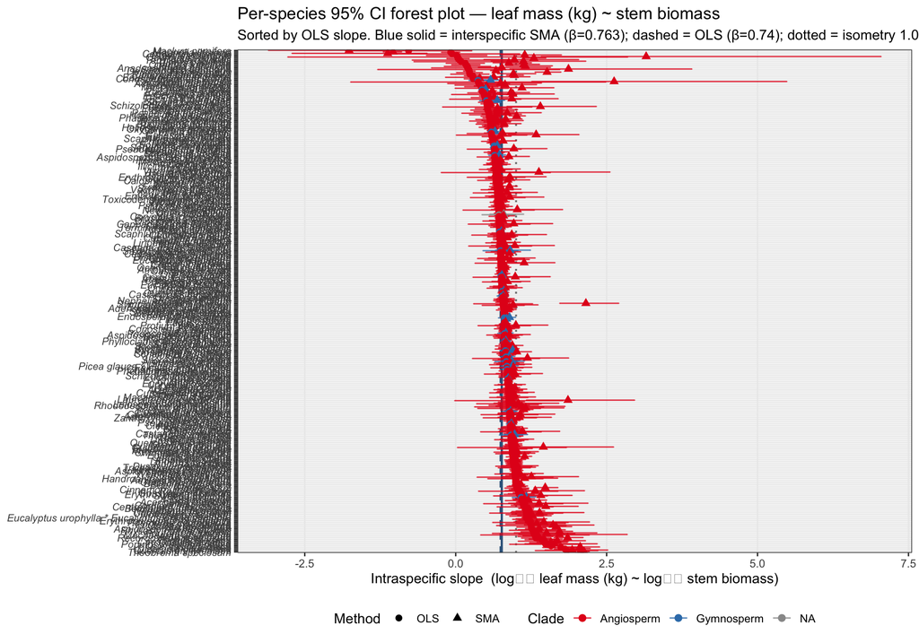

Per-species 95% confidence intervals for intraspecific scaling exponents (log10 leaf trait ~ log10 stem biomass). Circles = OLS, triangles = SMA, offset vertically. Species sorted by ascending OLS slope within each trait panel. Blue solid line = overall interspecific slope (SMA); blue dashed = interspecific OLS slope; grey dotted = isometry (slope = 1.0). Only species with n ≥ 8 individual records shown. Wide CIs indicate small n or narrow stem-mass range within that species.

```r
plot_stem_ci <- function(intra_df, ref_sma, ref_ols, trait_label) {
  if (nrow(intra_df) == 0) {
    cat("No eligible species for", trait_label, "\n")
    return(invisible(NULL))
  }
  ci_df <- intra_df |>
    arrange(ols_slope) |>
    mutate(sp_label = factor(speciesMatched, levels = rev(unique(speciesMatched)))) |>
    tidyr::pivot_longer(
      cols      = c(slope, ols_slope),
      names_to  = "method",
      values_to = "est"
    ) |>
    dplyr::mutate(
      lo     = dplyr::if_else(method == "slope", sma_ci_lo, ols_ci_lo),
      hi     = dplyr::if_else(method == "slope", sma_ci_hi, ols_ci_hi),
      method = dplyr::if_else(method == "slope", "SMA", "OLS"),
      method = factor(method, levels = c("OLS", "SMA"))
    ) |>
    dplyr::filter(is.finite(est), is.finite(lo), is.finite(hi))

  ggplot(ci_df,
         aes(x = est, y = sp_label, colour = clade, shape = method)) +
    geom_vline(xintercept = ref_sma, linetype = "solid",
               colour = "steelblue4", linewidth = 0.8) +
    geom_vline(xintercept = ref_ols,  linetype = "dashed",
               colour = "steelblue4", linewidth = 0.6) +
    geom_vline(xintercept = 1.00, linetype = "dotted",
               colour = "grey50", linewidth = 0.7) +
    geom_errorbarh(aes(xmin = lo, xmax = hi),
                   height    = 0.35,
                   linewidth = 0.50,
                   alpha     = 0.80,
                   position  = position_dodge(width = 0.60)) +
    geom_point(size     = 2.2,
               position = position_dodge(width = 0.60)) +
    scale_colour_manual(
      values  = c(Angiosperm = "#e41a1c", Gymnosperm = "#377eb8"),
      na.value = "grey60",
      name    = "Clade"
    ) +
    scale_shape_manual(values = c(OLS = 16, SMA = 17), name = "Method") +
    labs(
      x        = paste0("Intraspecific slope  (log\u2081\u2080 ", trait_label, " ~ log\u2081\u2080 stem biomass)"),
      y        = NULL,
      title    = paste0("Per-species 95% CI forest plot \u2014 ", trait_label, " ~ stem biomass"),
      subtitle = paste0("Sorted by OLS slope. Blue solid = interspecific SMA (\u03b2=", ref_sma,
                        "); dashed = OLS (\u03b2=", ref_ols, "); dotted = isometry 1.0")
    ) +
    theme_bw(base_size = 11) +
    theme(
      legend.position    = "bottom",
      strip.background   = element_rect(fill = "grey92"),
      axis.text.y        = element_text(size = 8, face = "italic"),
      panel.grid.major.y = element_line(colour = "grey90", linewidth = 0.3),
      panel.grid.minor   = element_blank()
    )
}

print(plot_stem_ci(intra_st_lf, sl_st_lf, ols_sl_st_lf, "leaf mass (kg)"))
```

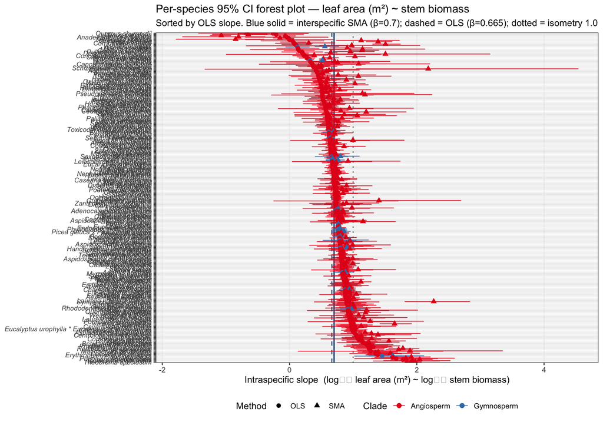

Per-species 95% CI forest plot for leaf area ~ stem biomass intraspecific slopes. Layout as above.

```r
print(plot_stem_ci(intra_st_al, sl_st_al, ols_sl_st_al, "leaf area (m\u00b2)"))
```

# 10 Methods note

- **Data source:** BAAD v1 (Falster et al. 2015), accessed via the `baad.data` R package. All measurements are individual-level.
- **OLS:** `lm()` on log₁₀-transformed data. Assumes all error is in the response variable; appropriate for prediction but biased for characterising bivariate allometric relationships when both axes carry measurement error.
- **SMA (Standardised Major Axis):** `smatr::sma()` (Warton et al. 2012, *Methods Ecol. Evol.* 3:257–259; Warton et al. 2006, *Biol. Rev.* 81:259–282). Appropriate when both axes carry error and the goal is to characterise the bivariate relationship rather than predict one from the other; standard for allometry.
- **PGLS (Phylogenetic Generalised Least Squares):** `caper::pgls()` fitted to species means; Pagel’s λ estimated by maximum likelihood; accounts for shared evolutionary history (Freckleton et al. 2002, *Am. Nat.* 160:712–726). Backbone phylogeny from V.PhyloMaker2 (Jin & Qian 2022, *J. Biogeography* 49:1731–1744; Qian & Jin 2016, *J. Systematics & Evolution* 54:380–388).
- **Angio/Gymno classification:** derived from the BAAD `pft` field (trailing letter A = Angiosperm, G = Gymnosperm). Records with missing `pft` are excluded from the clade-level comparisons.
- **Family-level analysis:** families with ≥ 30 individual records.
- **Intraspecific analysis:** species with ≥ 8 individual records having both AGB and the focal leaf trait. Slopes reflect ontogenetic or population-level size variation within each dataset contributing records for that species.
- **Theoretical benchmarks:** WBE/MST theory (Enquist & Niklas 2002) predicts leaf mass ∝ AGB^(3/4); isometry (slope = 1.0) would indicate constant leaf mass fraction regardless of plant size.